# 2) Benchmark Model Computation

As mentioned in the proposal, we are going to use a very simple indicator - Moving Average Convergence Divergence (MACD), to be our benchmark model for comparison. The formula of MACD is:

> $\text{MACD} = \text{EMA}_{12}(\text{price}) - \text{EMA}_{26}(\text{price})$  
> $\text{Signal} = \text{EMA}_{9}(\text{MACD})$  
> $\text{Divergence}_t = \text{MACD}_t - \text{Signal}_t$  
> $\text{Prediction} = \begin{cases} \text{Up} & \text{if } \text{Divergence}_t > 0 \text{ and } \text{Divergence}_{t - 1} < 0 \\ \text{Down} & \text{if } \text{Divergence}_t < 0 \text{ and } \text{Divergence}_{t - 1} > 0 \end{cases}$

### Data Reading

First of all, read all existing csv files in `input_data/`

```python
from IPython.core.display import display, HTML
display(HTML("<style>.container { width:100% !important; }</style>"))
```

```python
import pandas as pd
import numpy as np
import os
import sys


csv_file_list = [os.path.join('input_data', i) for i in sorted(os.listdir('input_data'))]
df_list = []
for ind, i in enumerate(csv_file_list):
    pct_ind = int((1 + ind) * 50 / len(csv_file_list))
    sys.stdout.write('\r')
    sys.stdout.write('Reading in progress: [{}{}] {}%'.format("=" * pct_ind, "-" * (50 - pct_ind), pct_ind * 100 / 50))
    df_list.append(pd.read_csv(i))
df = pd.concat(df_list).reset_index(drop=True)
print('\nFinished reading {} csv files and {} entries found'.format(len(csv_file_list), df.shape[0]))
```

```
Reading in progress: [==================================================] 100.0%
Finished reading 363 csv files and 517781 entries found
```

```python
df.head()
```

|  | date_time | open | high | low | close | volume |
| --- | --- | --- | --- | --- | --- | --- |
| 0 | 2020-01-01 00:00:00 | 7195.00 | 7200.25 | 7186.77 | 7200.25 | 57.777035 |
| 1 | 2020-01-01 00:01:00 | 7200.25 | 7220.37 | 7200.22 | 7217.70 | 76.136927 |
| 2 | 2020-01-01 00:02:00 | 7217.70 | 7220.81 | 7211.32 | 7215.01 | 41.826715 |
| 3 | 2020-01-01 00:03:00 | 7215.06 | 7221.99 | 7214.42 | 7217.57 | 18.940854 |
| 4 | 2020-01-01 00:04:00 | 7217.58 | 7218.98 | 7209.04 | 7211.65 | 39.764474 |

### MACD Computation

After reading all data, we can start computing the MACD signals according to the given formula.

```python
# MACD = EMA12(close) - EMA26(close)
df.loc[:, 'MACD'] = df['close'].ewm(span=12).mean() - df['close'].ewm(span=26).mean()

# Signal = EMA9(MACD)
df.loc[:, 'Signal'] = df['MACD'].ewm(span=9).mean()

# Divergence = MACD - Signal
df.loc[:, 'Divergence'] = df['MACD'] - df['Signal']
```

We can visualize the signal lines and divergence in two different graphs

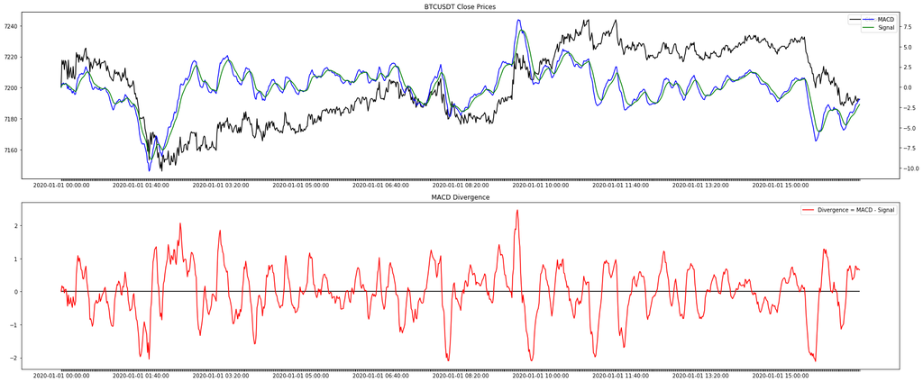

```python
import matplotlib.pyplot as plt

sub_df = df.loc[df.index[:1000]]

fig = plt.figure(figsize=(24, 10))
ax1 = plt.subplot(211)
ax2 = plt.subplot(212)

ts = sub_df['date_time'].tolist()

ax1.plot(ts, sub_df['close'], color='black', label='Close price')
ax1_sub = ax1.twinx()
ax1_sub.plot(ts, sub_df['MACD'], color='blue', label='MACD')
ax1_sub.plot(ts, sub_df['Signal'], color='green', label='Signal')
ax2.plot(ts, sub_df['Divergence'], color='red', label='Divergence = MACD - Signal')
ax2.hlines(0, xmin=[0], xmax=ts[-1])

ax1.set_title('BTCUSDT Close Prices')
ax1.legend(loc=0)
ax1_sub.legend()
ax2.set_title('MACD Divergence')
ax2.legend()

count = int(len(ts) / 10)
for n, labels in enumerate(zip(ax1.xaxis.get_ticklabels(), ax2.xaxis.get_ticklabels())):
    if n % count != 0:
        labels[0].set_visible(False)
        labels[1].set_visible(False)

ax1.get_shared_x_axes().join(ax1, ax2)
plt.tight_layout()
plt.show()
```

### Benchmark Evaluation

We can then define rules to measure accuracy of the predictions by MACD. As we mentioned before:

> $\text{Prediction} = \begin{cases} \text{Up} & \text{if } \text{Divergence}_t > 0 \text{ and } \text{Divergence}_{t - 1} < 0 \\ \text{Down} & \text{if } \text{Divergence}_t < 0 \text{ and } \text{Divergence}_{t - 1} > 0 \end{cases}$

We can split the predictions into 3 different windows: 1-minute (short-term), 10-mintue (medium-term) and 60-minute (long-term) price change direction. Under 3 different windows, we can further define the predictions to be:

> $\text{Let } x \text{ be the specific length of window}$  
> $\text{Forward } x \text{-minute Prediction} = \begin{cases} \text{Up} & \text{if } \text{Divergence}_t > 0 \text{ and } \text{Divergence}_{t - 1} < 0 \\ \text{Down} & \text{if } \text{Divergence}_t < 0 \text{ and } \text{Divergence}_{t - 1} > 0 \end{cases}$

Then we will calculate the accuracy of each case to evaluate how well this benchmark model performs. Since it is not a binary classification problem, normal meaures (precision & recall) may not work here. So we will use 2 custom metrics to evaluate its performance:

> $\text{Prediction Frequency} = \frac{\text{Total number of predictions made}}{\text{Total number of price changes}}$  
> $\text{Prediction Accuracy} = \frac{\text{Correct predictions}}{\text{Total number of predictions made}}$

Prediction Frequency can be used to measure whether a model is giving too infrequent signal that may be not insightful enough in our case.

```python
# First compute predictions from MACD signals
df.loc[:, 'prediction'] = [0.0, 0.0] + np.sign(np.diff(np.sign(df['Divergence']))).tolist()[1:]

# Then compute the target window forward changes for evaluation
for i in (1, 10, 60):
    df.loc[:, f'{i}m_fwd_chg_sign'] = np.sign(df.close.pct_change(i).shift(-i))
```

```python
# Then we can evaluate the accuracy of the predictions

result_metrics_dict = {}
for i in (1, 10, 60):
    col = f'{i}m_fwd_chg_sign'
    tmp_dict = {}
    sub_df = df.loc[:, ['prediction', col]].dropna()
    tmp_dict['prediction_frequency'] = sub_df.loc[sub_df['prediction'] != 0, :].shape[0] / sub_df.shape[0]
    tmp_dict['prediction_accuracy'] = sub_df.loc[sub_df['prediction'] == sub_df[col], :].shape[0] / sub_df.loc[sub_df['prediction'] != 0, :].shape[0]
    result_metrics_dict[f'{i}m_result'] = tmp_dict

print(pd.DataFrame(result_metrics_dict))
```

```
                      1m_result  10m_result  60m_result
prediction_frequency   0.081229    0.081229    0.081229
prediction_accuracy    0.541192    0.504922    0.491749
```

### Conclusion

From the above result, we can conclude that MACD model can give roughly 8 signals per 100 minutes / 5 signals per hour, with the best prediction at 1-minute forward changes (54% accuracy). Now the benchmark model is ready, and we are ready to work on the target model.